# PA1_template

### Introduction

It is now possible to collect a large amount of data about personal movement using activity monitoring devices such as a Fitbit, Nike Fuelband, or Jawbone Up. These type of devices are part of the “quantified self” movement – a group of enthusiasts who take measurements about themselves regularly to improve their health, to find patterns in their behavior, or because they are tech geeks. But these data remain under-utilized both because the raw data are hard to obtain and there is a lack of statistical methods and software for processing and interpreting the data.

This assignment makes use of data from a personal activity monitoring device. This device collects data at 5 minute intervals through out the day. The data consists of two months of data from an anonymous individual collected during the months of October and November, 2012 and include the number of steps taken in 5 minute intervals each day.

### Loading and preprocessing the data

This part of the code is necessary for the inital loading of the dataset

```r
  amd <- read.csv("activity.csv")
```

### What is mean total number of steps taken per day?

```r
  #Total number of steps/Median per day
  amd.NAless <- na.omit(amd)
  library(ggplot2)
  totalsteps <- tapply(amd.NAless$steps, amd.NAless$date, FUN=sum)

  head(totalsteps)
```

```
## 2012-10-01 2012-10-02 2012-10-03 2012-10-04 2012-10-05 2012-10-06
##         NA        126      11352      12116      13294      15420
```

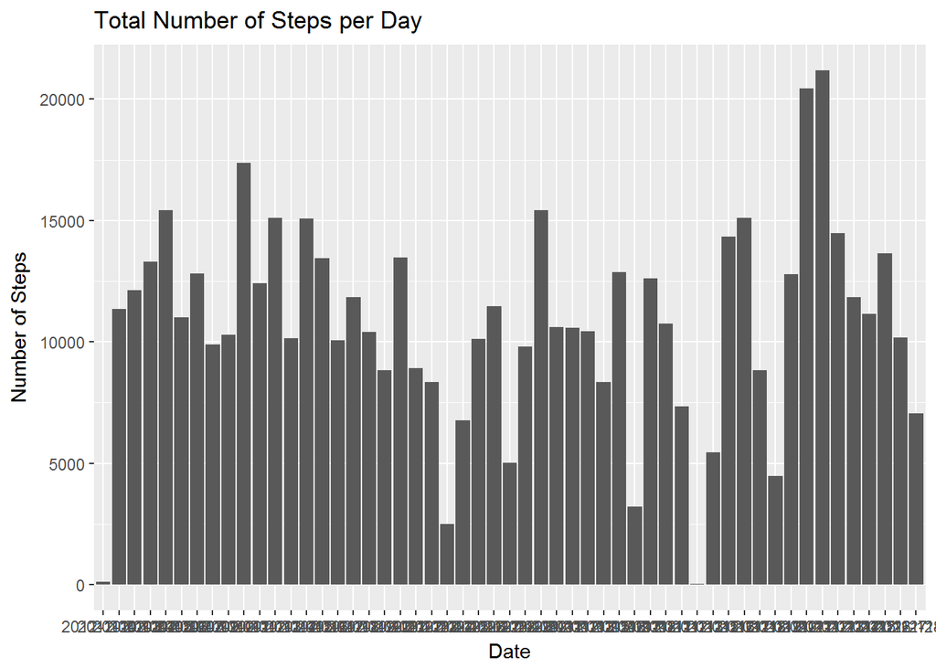

```r
  g <- ggplot(amd.NAless, aes(date,steps))
  g+geom_bar(stat="identity")+labs(title="Total Number of Steps per Day", x= "Date", y="Number of Steps")
```

Total number of steps/day

```
##    Min. 1st Qu.  Median    Mean 3rd Qu.    Max.    NA's
##      41    8841   10760   10770   13290   21190       8
```

The mean is 10770, and median is 10760